# Evolutionary Genomics & Bioinformatics

Bryanna Matias

8/31/2020

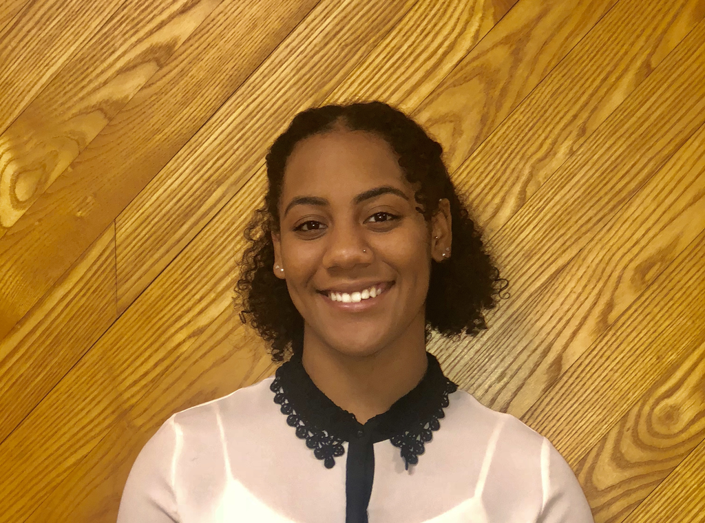

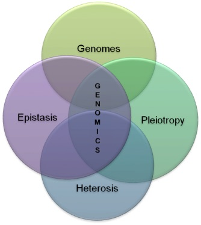

## R Labs

- Lab 1: Introduction to R and Reproducible Research
- Lab 2: Git, GitHub and Rstudio Project
- Lab 3A: Data Wrangling: Starting with Data
- Lab 3B: Data Wrangling: Manipulating data
- Lab 4: Data wrangling and graphing COVID-19 reporting data (Part 1)
- Lab 4A: Lab 4A/5A Exercises
- Lab 5: Data wrangling and graphing COVID-19 reporting data (Part 2)
- Lab 5x: Interactive Graphs and Animations from the COVID-19 reporting data
- Lab 6: Data Maps, Interactive Graphs and Animations from the COVID-19 reporting data
- Lab 7: RNA-Seq workflow: gene-level exploratory analysis and differential expression
- Lab 8: Sequence Alignment, Phylogenetic Analysis and Tree Visualization
- Lab 9: Programming in R - Regular Expressions
- Lab 9x: Programming in R - Control Structures and Functions
- Lab 10: Population genomics based on high throughput sequencing (HTS)
- Lab 11: Microbiome Analysis using dada2 and phyloseq
- Lab 11x: Microbiome Analysis using phyloseq
- Lab 12: Network Analysis using Cytoscape and RCy3
- Lab 13: Sprucing up your Rmarkdown and GitHub Page